# Ontwikkeling huizenprijs in Nederland

BvH

21 maart 2018

De volgende demo is bedoeld om het gebruik van [‘facet_geo’](https://hafen.github.io/geofacet/) te verduidelijken. Zie ook de blog-post [Introducing geofacet](http://ryanhafen.com/blog/geofacet).

Deze demonstratie toont de ontwikkeling van de huizenprijzen per provincie sinds 1995.

```r
#
# Laad data mbt de ontwikkeling van huizenprijzen in Nederland en toon per provincie.
#
# BvH 21-3-2018
#

library(tidyverse)

###############################################################################################################
# laad data
###############################################################################################################
huizenprijzen.r <-
  readr::read_csv2(file = "../data/Bestaande_koopwoningen_woningtype_81885NED_UntypedDataSet_21032018_214617.csv") %>%
  dplyr::filter(grepl("JJ00", Perioden)) %>%
  # selecteer de kolommen die jaar (en kwartaal) en bbp bevatten:
  dplyr::select(c("RegioS", "Perioden", "PrijsindexBestaandeKoopwoningen_1", "AantalVerkochteWoningen_4", "GemiddeldeVerkoopprijs_7")) %>%
  # hernoem kolom-namen:
  dplyr::rename(jaar = Perioden,
                regio = RegioS,
                prijsindex = PrijsindexBestaandeKoopwoningen_1,
                aantalVerkocht = AantalVerkochteWoningen_4,
                gemVerkoopprijs = GemiddeldeVerkoopprijs_7) %>%
  # waarden in juiste numerieke formaat omzetten:
  dplyr::mutate(jaar = as.integer(stringr::str_replace(jaar, "JJ00", "")))

# samenvoegen met metadata (namen van de provincies)
huizenprijzen.c <-
  readr::read_csv2(file = "../data/metadata_provincies.csv") %>%
  dplyr::full_join(huizenprijzen.r,
                   by = "regio")
```

Gebruik een voor-gedefinieerd grid voor het land of de regio waarvoor je een trend wilt tonen of definieer zelf een grid.

Voor de Nederlandse provincies is nog geen grid beschikbaar, dus dat definieeren we zelf.

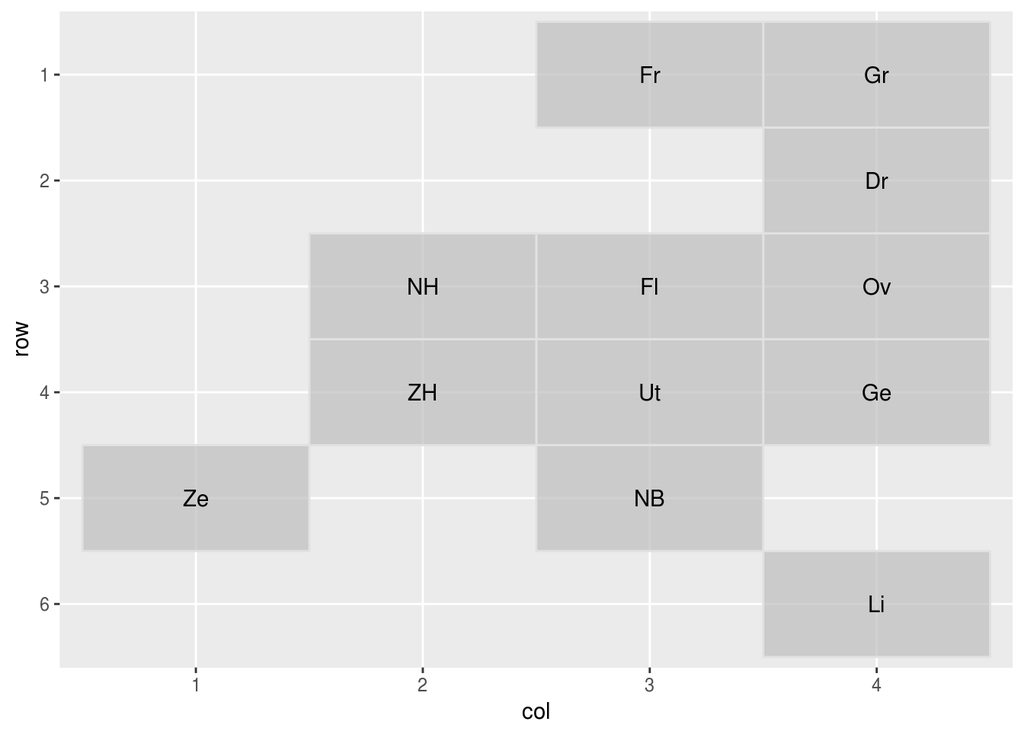

```r
library(geofacet)

###############################################################################################################
# toon data
###############################################################################################################
# definieer grid met de posities van de Nederlandse provincies
nl_province_grid1 <-
  data.frame(
  row = c(1, 1, 2, 3, 3, 3, 4, 4, 4, 5, 5, 6),
  col = c(4, 3, 4, 4, 3, 2, 4, 3, 2, 3, 1, 4),
  code = c("Gr", "Fr", "Dr", "Ov", "Fl", "NH", "Ge", "Ut", "ZH", "NB", "Ze", "Li"),
  name = c("Groningen", "Friesland", "Drenthe", "Overijssel", "Flevoland", "Noord-Holland", "Gelderland", "Utrecht", "Zuid-Holland", "Noord-Brabant", "Zeeland", "Limburg"),
  stringsAsFactors = FALSE)

# toon het grid
grid_preview(nl_province_grid1)
```

Dit lijkt (voor de kenner) we een beetje op de vorm van Nederland.

Kunnen we met dit grid op een visueel inzichtelijke en aantrekkelijke manier een beeld krijgen in de ontwikkeling per provincie? Bijvoorbeeld van de ontwikkeling van de prijsindex?

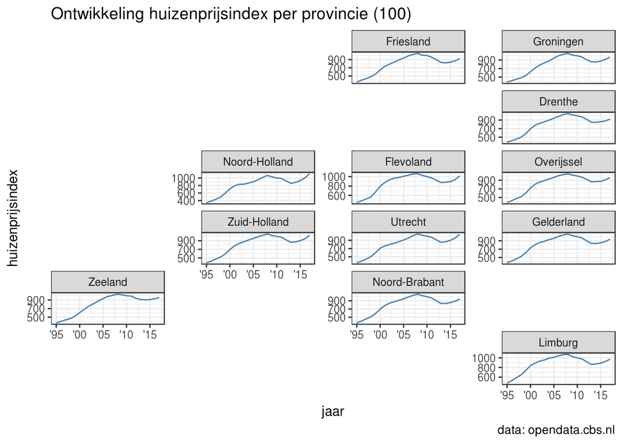

```r
# en laat zien wat je met zo'n grid en facet_geo kunt doen: toon de ontwikkeling per provincie.
ggplot(huizenprijzen.c,
       aes(jaar, prijsindex)) +
  geom_line(color = "steelblue") +
  facet_geo(~ provincie,
            grid = nl_province_grid1,
            scales = "free_y") +
  scale_x_continuous(labels = function(x) paste0("'", substr(x, 3, 4))) +
  labs(
    title = "Ontwikkeling huizenprijsindex per provincie (100)",
    caption = "data: opendata.cbs.nl",
    y = "huizenprijsindex") +
  theme_bw()
```

Hoe verhoudt zich het aantal verkochte huizen voor en na de economische crisis?

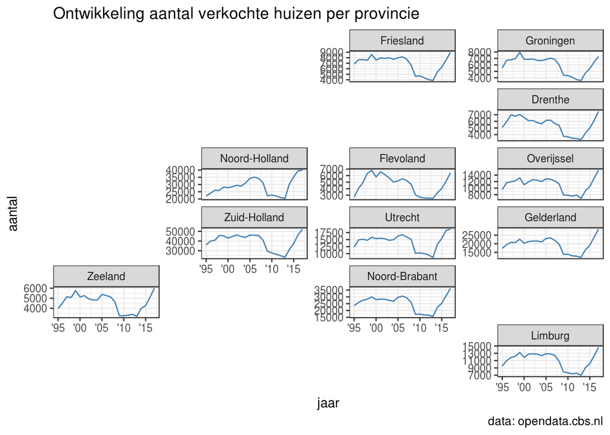

```r
ggplot(huizenprijzen.c,
       aes(jaar, aantalVerkocht)) +
  geom_line(color = "steelblue") +
  facet_geo(~ provincie,
            grid = nl_province_grid1,
            scales = "free_y") +
  scale_x_continuous(labels = function(x) paste0("'", substr(x, 3, 4))) +
  labs(
    title = "Ontwikkeling aantal verkochte huizen per provincie",
    caption = "data: opendata.cbs.nl",
    y = "aantal") +
  theme_bw()
```

Sinds de economie uit het dal is gekomen, is er een rechte lijn in de toename van het aantal verkochte huizen. Het valt op dat het aantal verkochte huizen in Noord-Holland de afgelopen jaren een plafond heeft bereikt.

Wat is de ontwikkeling van de gemiddelde huizenprijs?

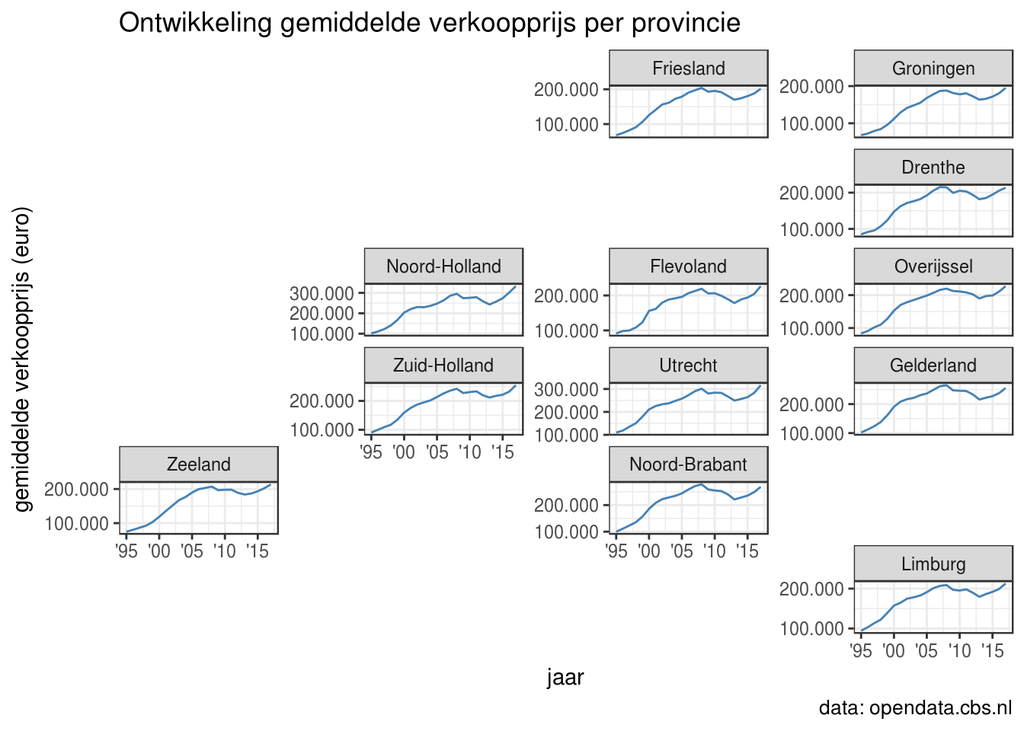

```r
library(scales)

point <- scales::format_format(big.mark = ".", decimal.mark = ",", scientific = FALSE)

ggplot(huizenprijzen.c,
       aes(jaar, gemVerkoopprijs)) +
  geom_line(color = "steelblue") +
  facet_geo(~ provincie,
            grid = nl_province_grid1,
            scales = "free_y") +
  scale_x_continuous(labels = function(x) paste0("'", substr(x, 3, 4))) +
  scale_y_continuous(breaks = c(100000, 200000, 300000),
                     labels = point) +
  labs(
    title = "Ontwikkeling gemiddelde verkoopprijs per provincie",
    caption = "data: opendata.cbs.nl",
    y = "gemiddelde verkoopprijs (euro)") +
  theme_bw()
```

Deze grafiek vertoond een vergelijkbare trend tussen de provincies. Maar de absolute waarde van de gemiddelde verkoopprijs van huizen verschilt per provincie. Daarom een tweede plot met een vaste y-as om de verschillen per provincie te benadrukken. Let op Noord-Holland (of eigenlijk Amsterdam…).

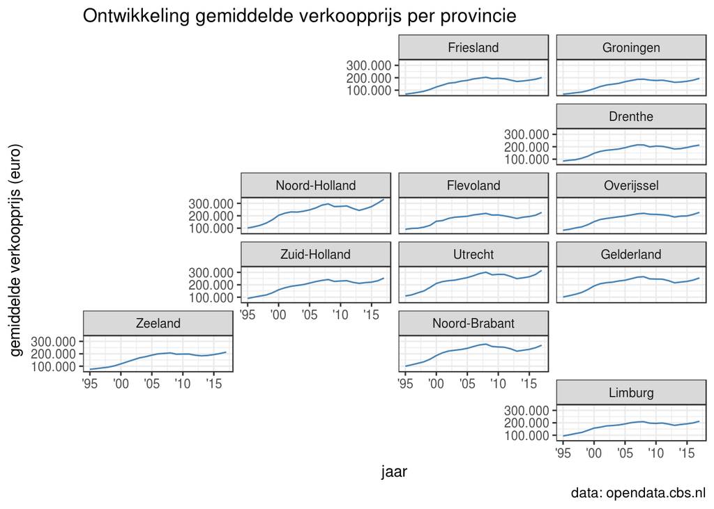

```r
ggplot(huizenprijzen.c,
       aes(jaar, gemVerkoopprijs)) +
  geom_line(color = "steelblue") +
  facet_geo(~ provincie,
            grid = nl_province_grid1) +
  scale_x_continuous(labels = function(x) paste0("'", substr(x, 3, 4))) +
  scale_y_continuous(breaks = c(100000, 200000, 300000),
                     labels = point) +
  labs(
    title = "Ontwikkeling gemiddelde verkoopprijs per provincie",
    caption = "data: opendata.cbs.nl",
    y = "gemiddelde verkoopprijs (euro)") +
  theme_bw()
```